# Intro to Text Mining

Pantea Ferdosian, Kevin Hoffman, Luke Moles, Marissa Shand

# 1 Preliminaries

This tutorial is intended for beginners to text mining with some knowledge of probability and R.

Link to GitHub repository: https://github.com/Marissa-Shand/Intro-to-Text-Mining

## 1.1 Required R Packages

We will be using the following R packages:

```r
library(tidyverse)
library(tidytext)
library(gutenbergr)
library(dplyr)
library(igraph)
library(ggraph)
library(topicmodels)
library(ldatuning)
library(ggpubr)

data(stop_words)
```

# 2 Text Mining Motivation

The amount of data that we produce every day is truly astonishing. With the evolution of communication through social media, we generate tons and tons of data. Out of all of this generated data, only around $20\%$ are Structured and well formatted. The remaining of the data is Unstructured Data. For instance, the bulk of emails we send, the text messages and the comments in social media are examples of Unstructured Data. These Unstructured data may be analyzed and mined in order to extract useful information.

Text Mining is the process of extracting meaningful information from unstructured natural language text data.

A few examples of how we use text mining every day:

- Auto-complete feature
- Spam Detection
- Predictive Typing
- Spell Checker

## 2.1 Terminology

**N-Gram:** a sequence of $n$ consecutive words or characters.

**Token:** “a meaningful unit of text, such as a word, that we are interested in using for analysis” [1]. This can be a word, n-gram, sentence or paragraph.

**Tokenization:** the process of splitting the whole data (corpus) into smaller chunks is known as tokenization. (i.e. sentences into words)

**Stop Words:** words that are very commonly used such as “although”, “really”, “from”, etc. By removing such words in a language, we can focus on the important words instead.

**Document Term Matrix (DTM):** A matrix containing the terms that appear in a collection of documents and the frequency of the terms, where rows represent the documents and columns represent the words (terms).

# 3 Extracting Important Words: TF-IDF

**How do we determine which words are the most important in a document?**

- TF term is short for *term frequency* which indicates how frequently a word appears in a document. The document most likely includes unimportant words which we classified earlier as *stop words*, but removing the stop words may not be the most efficient approach in this case because some of these words may be more important in some documents than others.
- IDF term or *inverse document frequency* defined as: $IDF(term) = ln(\frac{n_{documents}}{n_{documents\ containing\ term}})$. This method adjusts the weights and balances the usage of words across documents. It decreases the weight for widely used words and increases the weight for words that did not appear a lot.
- TF-IDF, which is short for *term frequency–inverse document frequency*, is a statistical measure that indicates how important a word is to a document in a collection. This is obtained by multiplying the two mentioned quantities, which would indicate “the frequency of a term adjusted for how rarely it is used”.

## 3.1 Example: Charles Dickens

To explore TF-IDF, we will examine several of Charles Dickens’ words. The titles of the books we will compare are *A Tale of Two Cities*, *Great Expectations*, *A Christmas Carol in Prose; Being a Ghost Story of Christmas*, *Oliver Twist*, *David Copperfield* and *Hard Times*. We will compare how the top 10 words with highest TF-IDF values in Charles Dickens’ works changes before and after removing stop words.

### 3.1.1 Before Removing Stop Words

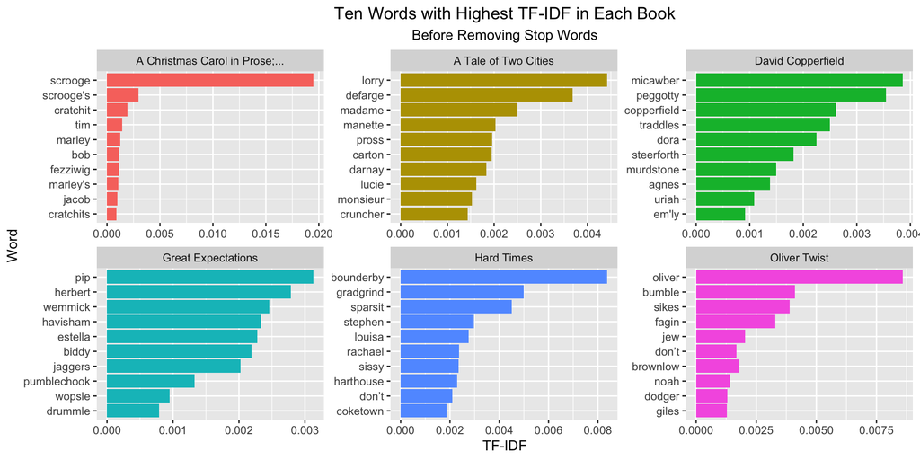

```r
## The Gutenberg IDs of the books we will be using are: 98, 1400, 46, 730, 766, 786
dickens_books <- gutenberg_download(c(98, 1400, 46, 730, 766, 786), meta_fields = "title")

## Tokenizing all the words in the 6 books
tidy_dickens <- dickens_books %>%
  unnest_tokens(word, text)

## Visualization of the 10 words with the highest TF-IDF in each book
tidy_dickens %>%
   count(title, word, sort = TRUE) %>%
   bind_tf_idf(word, title, n) %>%
   arrange(-tf_idf) %>%
   group_by(title) %>%
   top_n(10) %>%
   ungroup %>%
   mutate(word = reorder(word, tf_idf)) %>%
   ggplot(aes(word, tf_idf, fill = str_trunc(title, 30))) +
   geom_col(show.legend = FALSE) +
   facet_wrap(~ str_trunc(title, 30), scales = "free") +
   coord_flip() +
   labs(y = "TF-IDF",
        x = "Word",
        title = "Ten Words with Highest TF-IDF in Each Book",
        subtitle = "Before Removing Stop Words") +
   theme(plot.title = element_text(hjust = 0.5),
         plot.subtitle = element_text(hjust = 0.5))
```

### 3.1.2 After removing Stop words

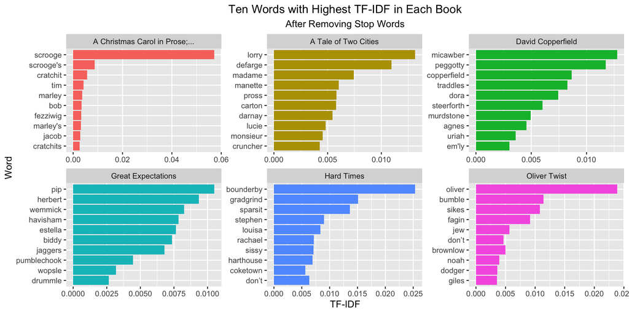

```r
## Remove stop words
tidy_dickens <- tidy_dickens %>% anti_join(stop_words, by = c("word" = "word"))

## Visualization of the 10 words with the highest TF-IDF in each book
tidy_dickens %>%
   count(title, word, sort = TRUE) %>%
   bind_tf_idf(word, title, n) %>%
   arrange(-tf_idf) %>%
   group_by(title) %>%
   top_n(10) %>%
   ungroup %>%
   mutate(word = reorder(word, tf_idf)) %>%
   ggplot(aes(word, tf_idf, fill = str_trunc(title, 30))) +
   geom_col(show.legend = FALSE) +
   facet_wrap(~ str_trunc(title, 30), scales = "free") +
   coord_flip()+
   labs(y = "TF-IDF",
        x = "Word",
        title = "Ten Words with Highest TF-IDF in Each Book",
        subtitle = "After Removing Stop Words") +
   theme(plot.title = element_text(hjust = 0.5),
         plot.subtitle = element_text(hjust = 0.5))
```

# 4 Sentiment Analysis

People are expressing their emotions now more than ever using the internet which provides plenty of data for researchers to use. Sentiment analysis is the process of analyzing the emotions of a given text. Some examples of sentiment analysis are analyzing tweets to analyze sentiments towards a political candidate, prioritize angry customer requests, and gauge brand reputation. Depending on the aim of your analysis, you can use one of several lexicons provided by the tidytext package to analyze the sentiment of a text.

## 4.1 Sentiment Lexicons

Within the tidytext library there are four lexicons for use [4]:

1. Bing - classifies words as positive or negative
   - Used to analyze generic sentiment about a text
   - 6783 unique words
   - 3 words have duplicate sentiment categories (envious, enviously, enviousness)*
2. AFINN - assigns each word a sentiment value between -5 and 5
   - Used to understand degree of positivity or negativity
   - 2477 unique words
   - Words do not have duplicate sentiment values
3. NRC - groups words into one of 10 different sentiment categories
   - Sentiment categories: {Anger, Anticipation, Disgust, Fear, Joy, Negative, Positive, Sadness, Surprise, Trust}
   - Used to evaluate the underlying emotion of a text
   - 6468 unique words
   - 3688 words have duplicate sentiment categories*
4. Loughran - groups words into one of 6 different sentiment categories
   - Sentiment categories: {Constraining, Litigious, Negative, Positive, Superfluous, Uncertainty}
   - Primarily used for financial text
   - 3917 unique words
   - 227 words have duplicate sentiment categories*

* Because words can have different meanings depending on the context, words can fall into different sentiment categories so there are duplicates in the dataset

### 4.1.1 Comparing AFINN and Bing

Because words can have different meanings depending on the context, words can fall into different sentiment categories so there are duplicates in the dataset. For simplicity, since this is a introduction to text mining, we will compare only AFINN and Bing because AFINN has no duplicate values and Bing has a duplicate category for only three words.

```r
## Sentiment lexicons
afinn <- get_sentiments('afinn')
bing <- get_sentiments('bing')
loughran <- get_sentiments('loughran')
nrc <- get_sentiments('nrc')
```

```r
## Join afinn and bing
afinn_bing <- afinn %>% inner_join(bing, by = c('word' = 'word')) %>%
   rename('bing_sentiment' = 'sentiment') %>%
   mutate(afinn_sentiment = ifelse(value >= 0, 'positive', 'negative'),
          same = afinn_sentiment == bing_sentiment)

## How many words do they disagree on?
dim(afinn_bing %>% filter(same == FALSE))[1]                      ## count
dim(afinn_bing %>% filter(same == FALSE))[1]/dim(afinn_bing)[1]   ## percent
```

## 4.2 Example: *A Tale of Two Cities* by Charles Dickens

Previously mentioned, different lexicons can be used to perform different analyses on text data. Since Bing assigns words to be either positive or negative, it can be used to determine general positivity or negativity of a text while AFINN can be used to determine the degree of positivity or negativity because it assigns each word a value between -5 and 5.

We will use both of these lexicons to analyze the sentiment of *A Tale of Two Cities* by Charles Dickens, “an 1859 historical novel … set in London and Paris before and during the French Revolution. The novel tells the story of the French Doctor Manette, his 18-year-long imprisonment in the Bastille in Paris and his release to live in London with his daughter Lucie, whom he had never met. The story is set against the conditions that led up to the French Revolution and the Reign of Terror.” [10].

It is important to note that the words envious, enviously, and enviousness do not appear in *A Tale of Two Cities*, so there will be no duplicate sentiments for any of the words in the document. The book begins with 137,388 words but 91,188 stop words were removed leaving 46,200 words for analysis.

```r
## We will be working with A Tale of Two Cities, which has id 98
two_cities <- gutenberg_download(98)

## There are three books that make up this book
## Get book number
two_cities <- two_cities %>% mutate(book = cumsum(str_detect(text, regex("^Book the"))),
                                    linenumber = row_number())

## For each book get the linenumber in the book, and the chapter
## Roman numerals: https://www.oreilly.com/library/view/regular-expressions-cookbook/9780596802837/ch06s09.html
two_cities <- two_cities %>% group_by(book) %>%
   mutate(book_linenumber = row_number(),
          chapter = cumsum(str_detect(text, regex("^(?=[MDCLXVI])M*(C[MD]|D?C{0,3})(X[CL]|L?X{0,3})(I[XV]|V?I{0,3})[.]")))) %>%
   ungroup()

## Convert to tidy text
two_cities <- two_cities %>% unnest_tokens(word, text)

## Remove stop words
## Solution to error: https://stackoverflow.com/questions/9221310/r-debugging-only-0s-may-be-mixed-with-negative-subscripts
tidy_two_cities <- two_cities %>% anti_join(stop_words, by = c("word" = "word"))

## How many words were removed?
dim(two_cities)[1]
dim(two_cities)[1] - dim(tidy_two_cities)[1]
dim(tidy_two_cities)[1]
```

### 4.2.1 Overall sentiment of *A Tale of Two Cities*

We will begin by examining the overall sentiment of *A Tale of Two Cities*, we will do this by considering the sentiment of all of the words excluding stop words.

**Bing**

Using the Bing sentiment lexicon, we can calculate the sentiment by looking at the number of positive words minus the number of negative words in the document to determine sentiment. If the associated value is greater than 0, this indicates that the text is generally positive. If the associated value is negative, this indicates that the text is generally negative. Finally, if the associated value is equal to 0, this means that the text is neutral. When we join the Bing sentiment lexicon with our data from *A Tale of Two Cities*, there are only 7,790 words in the book that have an associated Bing sentiment category, which represents only 16% of the words in the document after removing stop words.

$$Sentiment(text) = \# positive\ words - \# negative\ words$$

$$Sentiment(A\ Tale\ of\ Two\ Cities) = 2852 - 4938 = -2086$$

Since the associated sentiment is less than 0, this indicates that the overall sentiment of *A Tale of Two Cities* is negative.

```r
## Overall sentiment using Bing
## Join bing sentiment dataset with A Tale of Two Cities data
bing_two_cities <- tidy_two_cities %>% left_join(bing, by = c('word' = 'word')) %>% rename('bing' = 'sentiment')

## How many words have an associated bing sentiment?
dim(bing_two_cities %>% filter(!is.na(bing)))[1]
dim(bing_two_cities %>% filter(!is.na(bing)))[1]/dim(bing_two_cities)[1]

## Filter for words that have a bing sentiment category
bing_two_cities <- bing_two_cities %>% filter(!is.na(bing))

## Overall sentiment
num_positive <- dim(bing_two_cities %>% filter(bing == "positive"))[1]
num_negative <- dim(bing_two_cities %>% filter(bing != "positive"))[1]
overall_sentiment <- num_positive - num_negative
```

**AFINN**

Using the AFINN sentiment lexicon, we can calculate the sentiment by taking the mean of all of the sentiment values in the document. If the associated value is greater than 0, this indicates that the text is generally positive. If the associated value is negative, this indicates that the text is generally negative. Finally, if the associated value is equal to 0, this means that the text is neutral. When we join the AFINN sentiment lexicon with our data from *A Tale of Two Cities*, there are only 6,066 words in the book that have an associated AFINN sentiment value, which represents only 13% of the words in the document after we remove stop words. Let n be the number of words in the text that have an associated AFINN value.

$$Sentiment(text) = \frac{\sum_i AFINN_i}{n}$$

$$Sentiment(A\ Tale\ of\ Two\ Cities) = \frac{-2218}{6066} = -0.3656$$

```r
## Overall sentiment using AFINN
## Join sentiments with Tale of Two Cities
afinn_two_cities <- tidy_two_cities %>% left_join(afinn, by = c('word' = 'word')) %>% rename('afinn' = 'value')

## How many words have an associated afinn sentiment?
dim(afinn_two_cities %>% filter(!is.na(afinn)))[1]
dim(afinn_two_cities %>% filter(!is.na(afinn)))[1]/dim(afinn_two_cities)[1]

## Filter for words that have a sentiment value
afinn_two_cities <- afinn_two_cities %>% filter(!is.na(afinn))

## Overall sentiment
mean(afinn_two_cities$afinn)
```

### 4.2.2 Sentiment broken down by book and chapter: analyzing sentiment change over time

After analyzing the overall sentiment of *A Tale of Two Cities*, let’s now analyze how the sentiment changes over time. We will do this by first looking at the sentiment in each book, then in each chapter of the three books that make up *A Tale of Two Cities*.

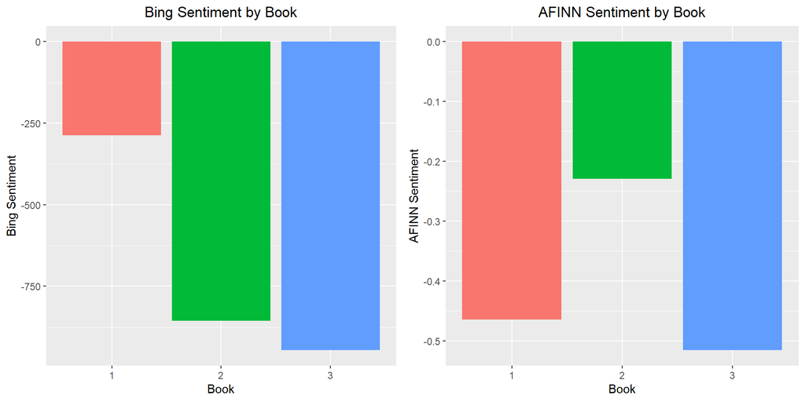

```r
## Code adapted from Text Mining with R [1]
## Make book a category instead of a numeric
bing_two_cities$book <- as.character(bing_two_cities$book)
afinn_two_cities$book <- as.character(afinn_two_cities$book)

## Sentiment of each book using Bing
overall_bing <- bing_two_cities %>%
   group_by(book) %>%
   summarize(num_pos = sum(bing == "positive"),
             num_neg = sum(bing == "negative"),
             sentiment = num_pos - num_neg) %>%
   filter(book > 0) %>%
   ggplot() +
   geom_bar(aes(x = book, y = sentiment, fill = book), stat = 'identity', show.legend = FALSE) +
   xlab("Book") +
   ylab("Bing Sentiment") +
   ggtitle("Bing Sentiment by Book") +
   theme(plot.title = element_text(hjust = 0.5))

## Sentiment of each book using AFINN
overall_afinn <- afinn_two_cities %>%
   group_by(book) %>%
   summarize(average_sentiment = mean(afinn)) %>%
   filter(book > 0) %>%
   ggplot() +
   geom_bar(aes(x = book, y = average_sentiment, fill = book), stat = 'identity', show.legend = FALSE) +
   xlab("Book") +
   ylab("AFINN Sentiment") +
   ggtitle("AFINN Sentiment by Book") +
   theme(plot.title = element_text(hjust = 0.5))

## Print these two plots side by side
## https://sebastiansauer.github.io/two-plots-rmd/
ggarrange(overall_bing, overall_afinn, ncol = 2)
```

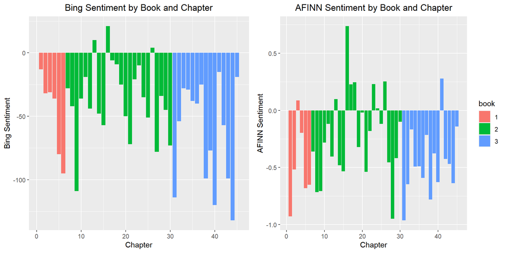

```r
## Code adapted from Text Mining with R [1]
## Sentiment of each chapter using Bing
chapter_bing <- bing_two_cities %>%
   filter(book > 0 & chapter > 0) %>%
   group_by(book, chapter) %>%
   arrange(book, chapter) %>%
   summarize(combo = cur_group_id(),
             num_pos = sum(bing == "positive"),
             num_neg = sum(bing == "negative"),
             sentiment = num_pos - num_neg) %>%
   ungroup()

chapter_bing_plot <- chapter_bing %>%
   ggplot() +
   geom_bar(aes(x = combo, y = sentiment, fill = book), stat = 'identity', show.legend = FALSE) +
   xlab("Chapter") +
   ylab("Bing Sentiment") +
   ggtitle("Bing Sentiment by Book and Chapter") +
   theme(plot.title = element_text(hjust = 0.5))

## Sentiment of each chapter using AFINN
chapter_afinn <- afinn_two_cities %>%
   filter(book > 0 & chapter > 0) %>%
   group_by(book, chapter) %>%
   arrange(book, chapter) %>%
   summarize(combo = cur_group_id(),
             average_sentiment = mean(afinn)) %>%
   ungroup()

chapter_afinn_plot <- chapter_afinn %>%
   ggplot() +
   geom_bar(aes(x = combo, y = average_sentiment, fill = book), stat = 'identity') +
   xlab("Chapter") +
   ylab("AFINN Sentiment") +
   ggtitle("AFINN Sentiment by Book and Chapter") +
   theme(plot.title = element_text(hjust = 0.5))

## Print these two plots side by side
ggarrange(chapter_bing_plot, chapter_afinn_plot, ncol = 2)
```

Just using the overall sentiment of *A Tale of Two Cities* or the sentiment of the books, it appears that the book is only negative. However, looking at the sentiment by chapter we can see that while most of the chapters are negative, but some are positive. A benefit of using AFINN over Bing is that it takes into consideration the magnitude of positivity or negativity of a word. Even if there were more negative words in a text, if the magnitude of positive words were greater than the magnitude of negative words, this could cause the sentiment to be positive. Here we can see that using the Bing sentiment lexicon, three of the chapters are classified as positive while using the AFINN sentiment lexicon, we classify nine chapters as positive.

Disadvantages of looking at words individually is that you cannot look at how they work together to form a sentence. In English, a double negative creates a positive.

# 5 Sequences of Words: N-Grams

It is sometimes useful to look at groups of words in order to understand how they can relate and build off one another. The n-grams of a passage are all the length $n$ sequences of words. For example, the bi-grams of “The quick brown fox jumped” are:

- the quick
- quick brown
- brown fox
- fox jumped

and the tri-grams are:

- the quick brown
- quick brown fox
- brown fox jumped

Notice that these n-grams can contain stop words, so it is often a good idea to filter out any results that include at least one. It is important, however, to mine n-grams before removing stop words. Otherwise, the cleaning will alter the sequences of words and provide incorrect results. In practice, we can mine text for all n-grams with lengths between some specified minimum and maximum, but we start here by extracting the bi-grams from *A Tale of Two Cities*.

```r
## Download book text
two_cities <- gutenberg_download(98)['text']

## Remove blank spaces
two_cities <- two_cities[two_cities$text != '',]

## Remove header material
two_cities <- two_cities[53:nrow(two_cities), ]

## Find all size 2 n-grams
## Filter out pairs with stopwords
stopwords <- stop_words$word
ngrams <- unnest_tokens(two_cities, ngram, text, token = 'ngrams', n = 2) %>%
  separate(col = ngram, into = c('first', 'second'), sep = ' ') %>%
  filter(!(first %in% stopwords)) %>%
  filter(!(second %in% stopwords))

print(paste('There are', nrow(ngrams), 'bi-grams without stopwords'))
```

```
## [1] "There are 11838 bi-grams without stopwords"
```

Even after removing the n-grams that contain stop words, there are still nearly 12,000 results. We can count the occurrences of each unique pair in order to reduce this number and get a better idea of which bi-grams are important.

```r
## Find the number of occurrences for each pair
## Take the top 50
ngrams <- ngrams %>%
  group_by(first, second) %>%
  summarize(n = n()) %>%
  arrange(desc(n)) %>%
  head(50) %>%
  ungroup()

head(ngrams)
```

| first | second | n |
| --- | --- | --- |
| miss | pross | 144 |
| madame | defarge | 113 |
| doctor | manette | 75 |
| charles | darnay | 51 |
| wine | shop | 51 |
| miss | manette | 49 |

Since this text is from a novel, the most common pairs represent the names of characters who are frequently mentioned. Still, some other results may be interesting. We can visualize these by treating the bi-grams as a directed graph.

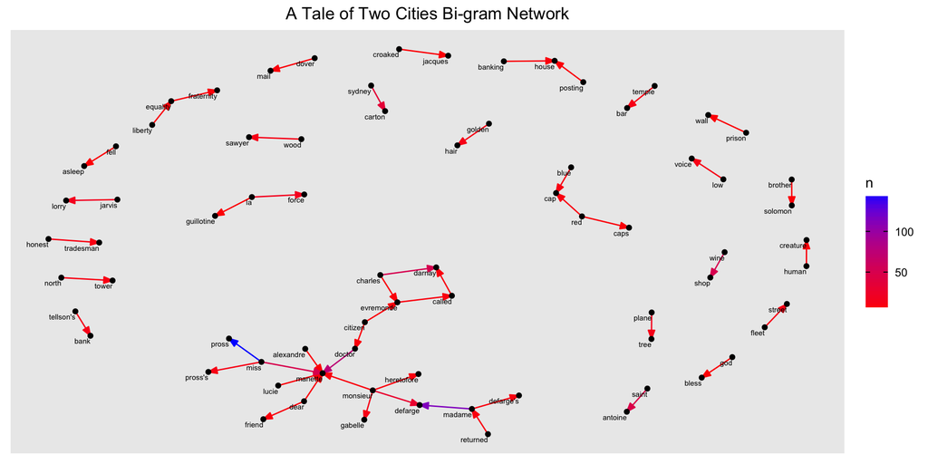

```r
## Reference for Bi-gram graph concept:
## Text Mining with R: a Tidy Approach (O'Reilly)
## Julia Sage, David Robinson

## Make a directed graph of bi-grams
g <- graph.data.frame(ngrams, directed = TRUE)

## Display graph

## Using ggraph package as recommended by reference
## Graphing help at: https://www.data-imaginist.com/2017/ggraph-introduction-edges/
ggraph(g, layout = 'kk') +
  geom_edge_link(arrow = arrow(angle = 20, type = 'closed', length = unit(0.1, 'inches')),
                 aes(color = n)) +
  geom_node_point() +
  geom_node_text(aes(label = name), size = 2, vjust = 1.5, hjust = 1) +
  scale_edge_color_gradient(low = 'red', high = 'blue') +
  ggtitle("A Tale of Two Cities Bi-gram Network") +
  theme(plot.title = element_text(hjust = 0.5))
```

The results show various isolated pairs corresponding to very specific bi-grams, but the more interesting sequences are those with overlapping words. These lead to larger connected clusters. The group of words in the bottom left of the graph seems to correspond to characters with similar names, or possibly frequent interaction. Expanding on this concept can lead to tree structures of text or generative methods, but those are beyond the scope of this tutorial.

## 5.1 TF-IDF with Bi-Grams

We can also calculate the TF-IDF scores for bi-grams in the works of Charles Dickens. This shows the most important pairs of words for each book.

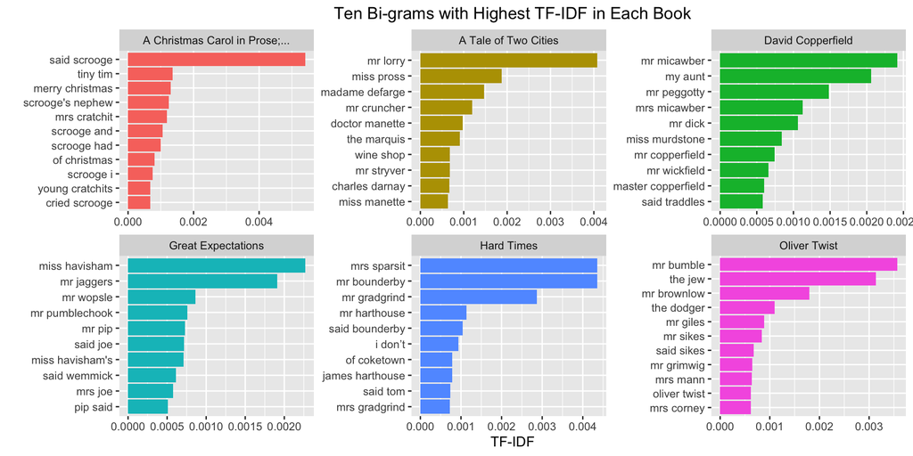

```r
dickens_books <- gutenberg_download(c(98, 1400, 46, 730, 766, 786), meta_fields = "title")

## Tokenizing all the bi-grams in the 6 books
tidy_dickens <- dickens_books %>%
  unnest_tokens(ngram, text, token = 'ngrams', n = 2)

## Visualization of the 10 bi-grams with the highest TF-IDF in each book
tidy_dickens %>%
   count(title, ngram, sort = TRUE) %>%
   bind_tf_idf(ngram, title, n) %>%
   arrange(-tf_idf) %>%
   group_by(title) %>%
   top_n(10) %>%
   ungroup %>%
   mutate(ngram = reorder(ngram, tf_idf)) %>%
   ggplot(aes(ngram, tf_idf, fill = str_trunc(title, 30))) +
   geom_col(show.legend = FALSE) +
   facet_wrap(~ str_trunc(title, 30), scales = "free") +
   coord_flip() +
   labs(y = "TF-IDF",
        x = "",
        title = "Ten Bi-grams with Highest TF-IDF in Each Book") +
   theme(plot.title = element_text(hjust = 0.5),
         plot.subtitle = element_text(hjust = 0.5))
```

When we compare the results of TF-IDF here to the results with single word tokenization, we can see the emphasis on complete character names and, in some cases, actions of characters. By including stop words in this, we also have the opportunity to see words that would never be significant on their own, but can be important as part of a sequence.

# 6 Topic Modeling

Topic modeling is an unsupervised method of clustering words from documents into topics. It is unsupervised because we do not know the true topics for the words, but our goal is to discover latent or hidden patterns in the collection of documents. It is similar to clustering numeric data. One example of a use case is if you were a paralegal and had a large batch of emails from discovery, you could use topic modeling to try to identify the topics people were writing about without having to read every document.

## 6.1 Latent Direchlet Allocation

One of the most popular methods for topic modeling is Latent Dirichlet Allocation. Latent Dirichlet Allocation is a probabilistic generative model where each document is a collection of topics and each topic is a collection of words [5]. For example, a document could be comprised of 60% of one topic and 40% of another topic. By looking at the collection of words in a topic, you could infer the meaning. If the first topic was made of 40% of the word apple, 25% of the word orange, etc. the topic could be fruit. Below is a graphical model of LDA:

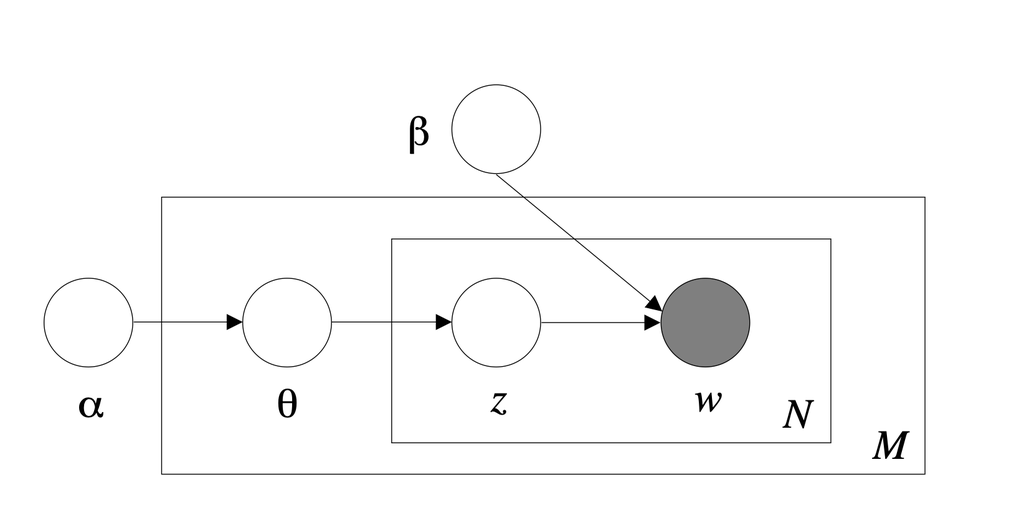

$\alpha$ is a hyperparameter on the Dirichlet distribution of $\theta$, where $\theta$ is the probabilities of topics in documents.

$\beta$ is a hyperparameter on the Dirichlet distribution of words in a particular document.

$M$ represents the number of topics and $N$ represents the number of words.

$z$ are the topics and $w$ are the words. $w$ is shaded because it is a known variable.

For the LDA model, first you choose the values of your hyperparameters and $M$, the number of topics. For each of the $N$ words, we want to choose a topic $z_n$ from the multinomial ($\theta$) distribution, which represents the distribution of topics in each document. Then we want to choose a word $w_n$ from the conditional probability $p(w_n|z_n,\beta)$ which is the probability of the word given the document. After going through each word and assigning the proportion of words to topics and topics to documents, we repeat this process a specified number of times.

## 6.2 Example: Clustering Books by Author

To show how LDA can work in practice, let’s consider an example. Say you have 20 book titles from the top 10 authors from the Project Gutenberg and want to know how many distinct authors wrote the set of books and which books were written by the same author. We can use topic modeling to cluster the books into topics which presumably represent the authors of the books.

### 6.2.1 Obtaining and Preparing the Texts

First we’ll create an array of the popular author names and then obtain all books by these authors from Project Gutenberg. We will limit our selection to works written in English and ignore collections and parts of works.

```r
## Set of popular authors
authors.popular <-
   c(
      "Dickens, Charles",
      "Austen, Jane",
      "Shelley, Mary Wollstonecraft",
      "Twain, Mark",
      "Doyle, Arthur Conan",
      "Wilde, Oscar",
      "Leech, John",
      "Hawthorne, Nathaniel",
      "Stevenson, Robert Louis",
      "Carroll, Lewis"
   )

## Create list of words that appear in titles to remove parts of books, collections, and letters of the author
ignore.strings <- c("Works", "Part", "Volume", "Chapters", "From \"", "From:")

## Get books from the popular authors listed above
books.authors.popular <- gutenberg_metadata %>%
   filter(
      author %in% authors.popular,
      language == "en", # Only English works
      !str_detect(title, paste(ignore.strings, collapse = "|")),
      has_text,
      !str_detect(rights, "Copyright") # Ignore copyrighted works
   ) %>%
   distinct(title, .keep_all = TRUE) %>% # Remove duplicate titles
   select(gutenberg_id, title, author)
```

Next, select a random sample of 20 books and download them.

```r
## Sample 20 books from the books from popular authors
set.seed(905)
books.selection <- books.authors.popular %>% sample_n(20)

## Download the 20 books
books.list <-
   books.selection$gutenberg_id %>% gutenberg_download(meta_fields = "title")
```

Now we have the text of all 20 books in a data frame. We will need to remove blank rows of the text and use the unnest_tokens function from the tidytext package to split our columns of text into one word per row for each document.

```r
## Clean the data from the selected books
books.text <- books.list %>%
   filter(text != '') %>% # Remove blank lines
   select(-gutenberg_id) %>% # Drop the id
   group_by(title)  %>%
   unite(document, title)

## Perform tokenization
words.by.book <- books.text %>%
   unnest_tokens(word, text)
```

Next we will calculate how many times each word appears in each document so we can turn our data into a Document Term Matrix to run the LDA model. We will also remove stop words.

```r
## Remove stop words, numbers, and text that begins with an underscores
## Then get the frequency of each of these words
word.counts <- words.by.book %>%
   anti_join(stop_words) %>% # Remove stop words
   filter(
   !str_detect(word, "[0-9]"), # Remove words that are numbers
   !str_detect(word, "^_"), # Remove text that starts with an underscore
   ) %>%
   count(document, word, sort = TRUE) %>%
   ungroup()

## Create a Document Term Matrix
books.dtm <- word.counts %>%
   cast_dtm(document, word, n)
```

### 6.2.2 LDA Model

To run the LDA model from the topicmodels package, we will also have to select a $k$ for the number of topics (authors). Let’s try 5.

```r
## Run an LDA model with k = 5
books.lda <- LDA(books.dtm, k = 5, control = list(seed = 600))
```

After running the model, we can obtain the probabilities of each word belonging to each topic from the beta matrix in tidy. This is the conditional probability $p(w_n|z_n,\beta)$ in the graphical LDA model. It will return a row for every word and topic and the associated probability. Let’s graph the 7 most likely words in each topic.

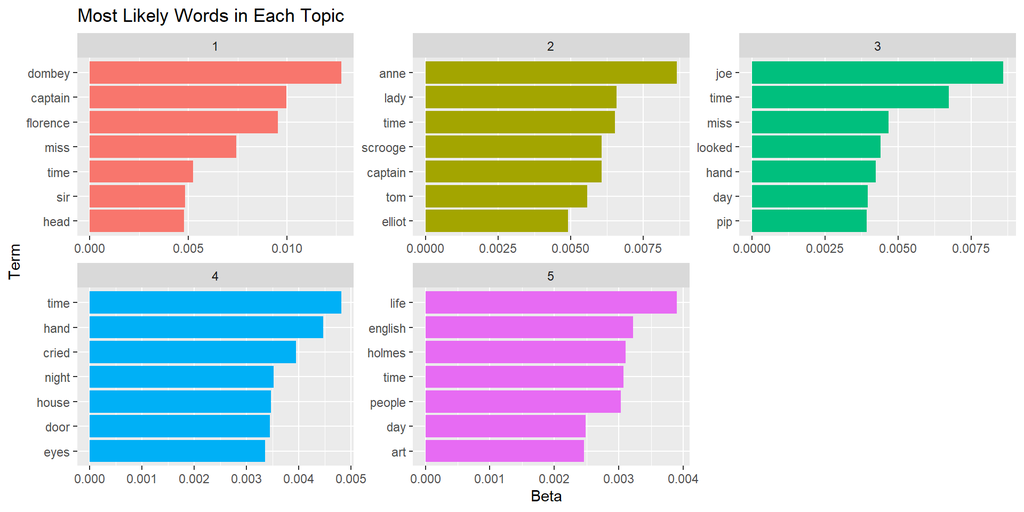

```r
## Identify the 7 most likely words in each topic
## Source: https://www.tidytextmining.com/topicmodeling.html#word-topic-probabilities
books.topics <- tidy(books.lda, matrix = "beta") # Extract beta - the probability a word comes from a topic

words.top <- books.topics %>%
   group_by(topic) %>%
   top_n(7, beta) %>% # Get the top 7 probabilities in each topic
   ungroup() %>%
   mutate(term = reorder_within(term, beta, topic)) # Sort the betas within each topic

## Visualize the 7 most likely words in each topic
ggplot(words.top, aes(beta, term, fill = factor(topic))) +
   facet_wrap(~ topic, scales = "free") +
   scale_y_reordered() +
   geom_col(show.legend = FALSE) +
   labs(title = "Most Likely Words in Each Topic", x = "Beta", y = "Term")
```

Let’s look at some interesting words or names in topic 1 such as “dombey” and “florence”.

```r
## Filter word counts for "dombey"
word.counts %>% filter(word == "dombey")
```

| document | word | n |
| --- | --- | --- |
| Dombey and Son | dombey | 1545 |

```r
## Filter word counts for "florence"
word.counts %>% filter(word == "florence")
```

| document | word | n |
| --- | --- | --- |
| Dombey and Son | florence | 1156 |
| The $30,000 Bequest, and Other Stories | florence | 5 |

“domebey” and “florence” both appear most often from *Dombey and Son* so it is a good sign that words from the same document are grouped in the same topic. We know we have up to 10 authors, but we do not know the exact number because we sampled from all of their works. We need to run this LDA model for each possible number of authors and use an evaluation metric to determine which is the best “fit” for the different clusters. We can use the ldatuning package to do this for us. The package provides a metric called “Arun2010” that we will use to determine which k to use for our model. We want to select $k$ that is the smallest as this metric measures the K-L divergence and this value is higher for non-optimal values of $k$ [8].

```r
## Find the optimal number of topics trying k = 1 to k = 10 and print the result
topics.results <- FindTopicsNumber(
      books.dtm,
      control = list(seed = 455),
      topics = seq(1, 10),
      metrics = "Arun2010",
      method = "Gibbs"
)

## Sort by the Arun2010 metric ascending
topics.results %>% arrange(Arun2010)
```

| topics | Arun2010 |
| --- | --- |
| 8 | 8.453013 |
| 9 | 8.763095 |
| 10 | 9.283758 |
| 6 | 10.014402 |
| 7 | 10.141480 |
| 5 | 10.257533 |
| 4 | 11.355737 |
| 3 | 12.570214 |
| 2 | 14.290353 |

### 6.2.3 Results

The k with the lowest Arun2010 score is 8 so we will run our LDA model again with $k = 8$ and look at the top word probabilities and see how they have changed. Topic 1 when $k = 5$ is now topic 6, except “toots” replaces “head” as one of the likely words to appear in that topic. Topic 4 in the $k = 8$ model contains words that were not the most likely for any topics in the $k = 5$ model such as “mother”, “dear”, and “vernon”.

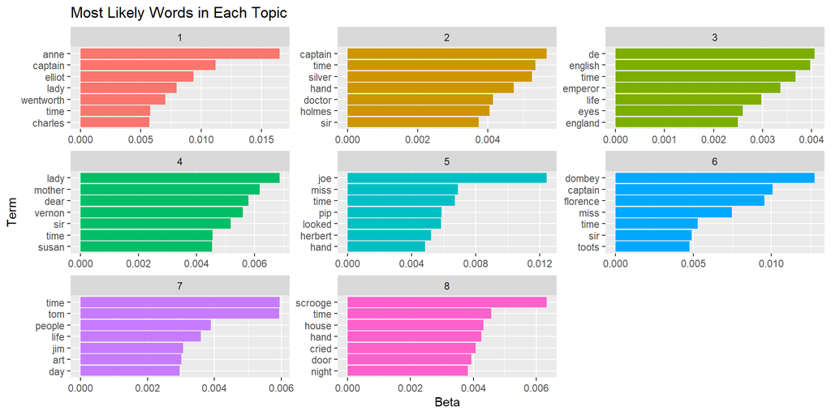

```r
## Run LDA with optimal number of topics
books.lda.optimal <- LDA(books.dtm, k = 8, control = list(seed = 555))

books.topics.optimal <- tidy(books.lda.optimal, matrix = "beta") # Extract beta - the probability a word comes from a topic

words.top.optimal <- books.topics.optimal %>%
   group_by(topic) %>%
   top_n(7, beta) %>% # Get the top 7 probabilities in each topic
   ungroup() %>%
   mutate(term = reorder_within(term, beta, topic))  # Sort the betas within each topic

## Visualize the 7 most likely words in each topic
ggplot(words.top.optimal, aes(beta, term, fill = factor(topic))) +
   facet_wrap(~ topic, scales = "free") +
   scale_y_reordered() +
   geom_col(show.legend = FALSE) +
   labs(title = "Most Likely Words in Each Topic", x = "Beta", y = "Term")
```

We can also look at the composition of topics in each document by extracting the gamma values from our LDA model, which represents the probability of a topic given the document. This is $\theta$ in the LDA graphical model in the previous section. Since each book (document) is written by a different author (topic), we expect that each document should be made up of only one topic. This holds true for almost all the books and every book has 1 dominant topic.

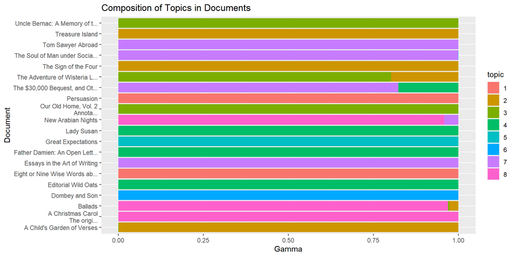

```r
## Get the topic probabilities given the document
books.docs.optimal <- tidy(books.lda.optimal, matrix = "gamma")

## Plot the composition of topics of each document
books.docs.optimal %>%
   group_by(document) %>%  # Group by each book
   ggplot(aes(x=str_trunc(document, 30), y=gamma, fill=factor(topic))) +
   geom_bar(stat='identity') +
   coord_flip() + # Plot horizontally
   labs(title = "Composition of Topics in Documents", x = "Document", y = "Gamma", fill = "topic")
```

Let’s compare the number of unique authors in our 20 books to the $k$ we selected. Also we will examine the authors in each topic to see how LDA groups them.

```r
## How many authors did we sample in the beginning?
as.numeric(books.selection %>% distinct(author) %>% count())
```

```
## [1] 8
```

```r
## Create a table of topics and authors
books.docs.optimal %>%
   group_by(document) %>%  # Group by each book
   top_n(n=1) %>% # Select the max gamma for each book
   rename("title"="document")  %>% # Rename document to title to join on the authors
   left_join(books.selection) %>%
   group_by(topic) %>%
   summarise(authors = paste(author, collapse = "; ")) # Combine the authors for each topic into one row
```

| topic | authors |
| --- | --- |
| 1 | Austen, Jane; Carroll, Lewis |
| 2 | Stevenson, Robert Louis; Doyle, Arthur Conan; Stevenson, Robert Louis |
| 3 | Doyle, Arthur Conan; Hawthorne, Nathaniel; Doyle, Arthur Conan |
| 4 | Austen, Jane; Stevenson, Robert Louis; Twain, Mark |
| 5 | Dickens, Charles |
| 6 | Dickens, Charles |
| 7 | Twain, Mark; Twain, Mark; Wilde, Oscar; Stevenson, Robert Louis |
| 8 | Dickens, Charles; Stevenson, Robert Louis; Stevenson, Robert Louis |

We did select the same number of topics as authors in our book set, but our LDA model did not quite put the distinct authors into each topic. Some topics contained multiples of the same author such as the second topic contains 2 books by Robert Stevenson, but it contains a third book by Arthur Doyle. Topics 5 and 6 only have one book and they are written by by Charles Dickens. The model may not have enough examples for each author to distinguish between them as we only used 20 books. Even though we used the same number of topics as authors, LDA finds latent patterns in text, which can be different than what we expect. One way to try to identify the meaning of the topics is to examine common and rare words and identify similarities between them and consider their source.

# 7 References

1. [Text Mining with R](https://www.tidytextmining.com/index.html)
2. [Project Gutenberg](https://www.gutenberg.org/)
3. [Roman Numerals with Regex](https://www.oreilly.com/library/view/regular-expressions-cookbook/9780596802837/ch06s09.html)
4. [Sentiment Datasets](https://www.datacamp.com/community/tutorials/sentiment-analysis-R)
5. [Latent Dirichlet Allocation](http://www.cse.cuhk.edu.hk/irwin.king/_media/presentations/latent_dirichlet_allocation.pdf)
6. [TF-IDF](https://cran.r-project.org/web/packages/tidytext/vignettes/tf_idf.html)
7. [Loughran Sentiment Dataset](https://www.rdocumentation.org/packages/tidytext/versions/0.2.0/topics/sentiments)
8. [On Finding the Natural Number of Topics with Latent Dirichlet Allocation](https://doi.org/10.1007/978-3-642-13657-3_43)
9. [Sentiment Analysis](https://monkeylearn.com/sentiment-analysis/)
10. [A Tale of Two Cities Summary](https://en.wikipedia.org/wiki/A_Tale_of_Two_Cities)